# KSIndividualAssignment1

# The plot function specifies the variables of the scatter plot with the x variable being vaccination rate and the y variable being case_count and the main title for the scatter plot being vaccination rates vs covid infection rates. xlab and ylab shows the x and y axis titles of the scatterplot.

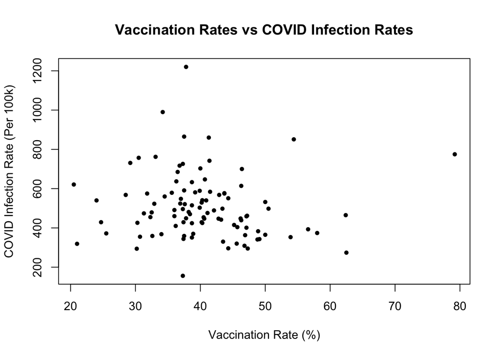

```r
plot(x = vaccination_rate, # x coordinate
     y = case_count, # y coordinate
     pch = 20,
     main = "Vaccination Rates vs COVID Infection Rates", # title of scatterplot
     xlab = 'Vaccination Rate (%)', #x axis title
     ylab = 'COVID Infection Rate (Per 100k)' # y axis title
     )
```

The for loop uses i as the iterable variable to iterate over the the length from 1 to the vector length of the durham_counties, and the points are plotted for x and y by looking at filtered_vaccination rates for the iterable variable i passing through the iteration of 1 to the vector length of the durham counties by looking at the vaccination rate versus the covid infection rate, hence plotting (x,y) per point. col = blue specifies the plot points in the scatter plot in the color blue of the durham counties for where they are in the graph with vaccination rate versus covid infection rate.

? what does this mean? The for loop uses i as the iterable variable to loop through the iteration in the for loop figure out coordinates of the durham counties and to plot it

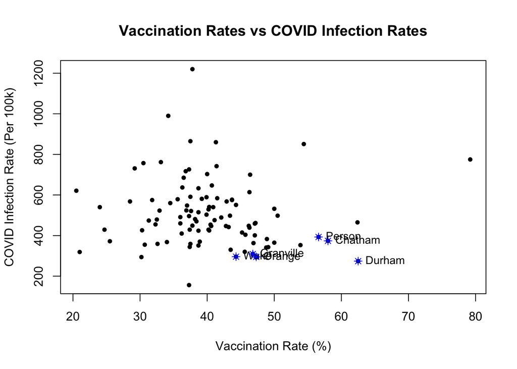

```r
plot(x = vaccination_rate, # x coordinate
     y = case_count, # y coordinate
     pch = 20,
     main = "Vaccination Rates vs COVID Infection Rates", # title of scatterplot
     xlab = 'Vaccination Rate (%)', #x axis title
     ylab = 'COVID Infection Rate (Per 100k)' # y axis title
     )

for (i in 1:length(durham_counties)){ # i loops through 1:length(durham_counties)
  points(x = filtered_vax[i], y = filtered_cases[i], pch = 8, col = 'blue') #x and y coordinates are specified for filtered_vax and filtered_cases, and blue color
  text(x = filtered_vax[i], y = filtered_cases[i], labels = durham_counties[i], # specifies text with text function
       cex=.9, font=1.5, pos=4) #specifies symbol size, font, and part of speech
}
```